# Prioritization of Denmark and EU

27/10, 2022

## Species distirbution models

## Species distribution models

- Modeling more than 40,000 Species of Denmark
- Goal to model them at 10 meter resolution including
  - Climatic data (Chelsa Downscaling algorithm)
  - Soil data (Soilgrids for EU)
  - Landuse (Either corine or google earth dynamic world)
- Projections for present and at least 4 future scenarios

## Presence cleaning

- Passed it through the **taxize** r package to get the GBIF closest match and exclude synonimia
- Filtered out species with lower than 0.9 in a match
- Used **rgbif** package to download presences
- Max 10.000 species that had coordinates

## Filtering of presences

With **CoordinateCleaner** r package:

- Presences from 1960 onwards
- Eliminated prescences in Country, county or regions centroids (Known way to create coordinates of occurrences where there are no known coordinates)
- Eliminated equal lat and long
- Eliminated environmental and geografical outliers

With **spThin**

- Made sure that presences are at least 5 kms form each other (Spatial Autocorrelation)

## Example

For **Avena fatua** reduction from 6406 to 1458

[interactive chart not shown]

## Methods

- Using AMPL written and tested models to prioritize:
  - Denmark or EU as a whole, by region, or by commune
  - Maximize shannon divesity (or other alpha div)
  - Select possible landuse changes
  - Minimum Carbon storage
  - Goals for red list species
  - Consider cities, landuse change, and climate change

## Methods

- Using prioritizr for optimization
- two approaches
  - Minimum cost to approach goals
  - Maximum gain given a certain budget (better to get to target areas)
- 987 species as target features

## Biodiversity

## Data for Denmark

- From BIEN, we looked for all the presences of species present in Denmark
  - Native: 987
  - Invasive: 208 (more introduced species have also been modeled)
- Model current and 4 future scenarios

## Concensus (Example)

- When current and future ranges are aligned

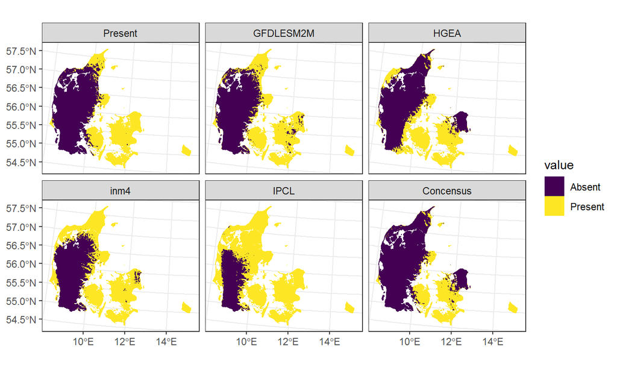

## Concensus richness

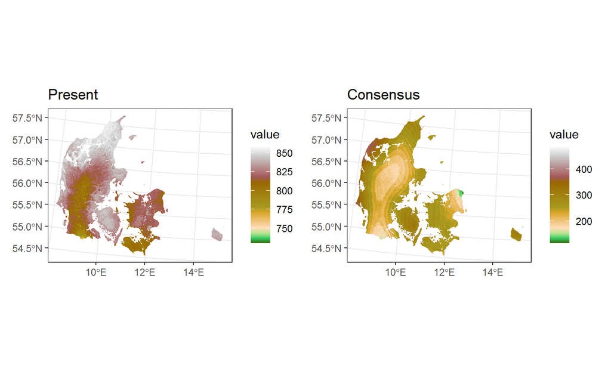

- Present richness vs concensus richness
- Better options with migrations, artscore, and other metrics
- Other taxa

## Human dimension

## Agriculture

- Naidoo and Iwamura (2007)
- Based on potential crop and livestock production
- Does not consider climate change (We can do better)

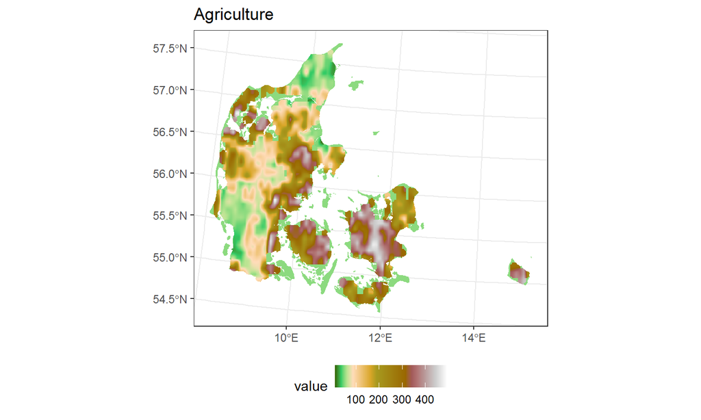

## Human footprint

- Copenhagen shows how different they are

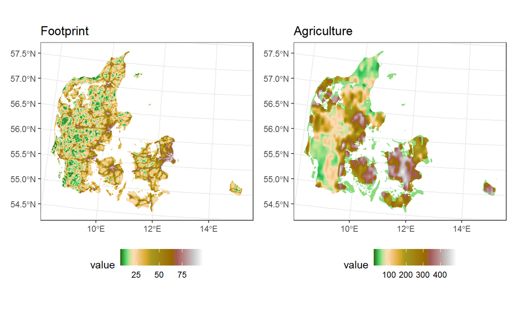

## Prioritization

## Naive prioritization

- Only take into account species (10% coverage)

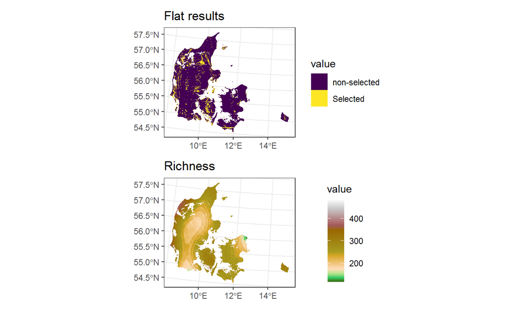

## Naive (cont)

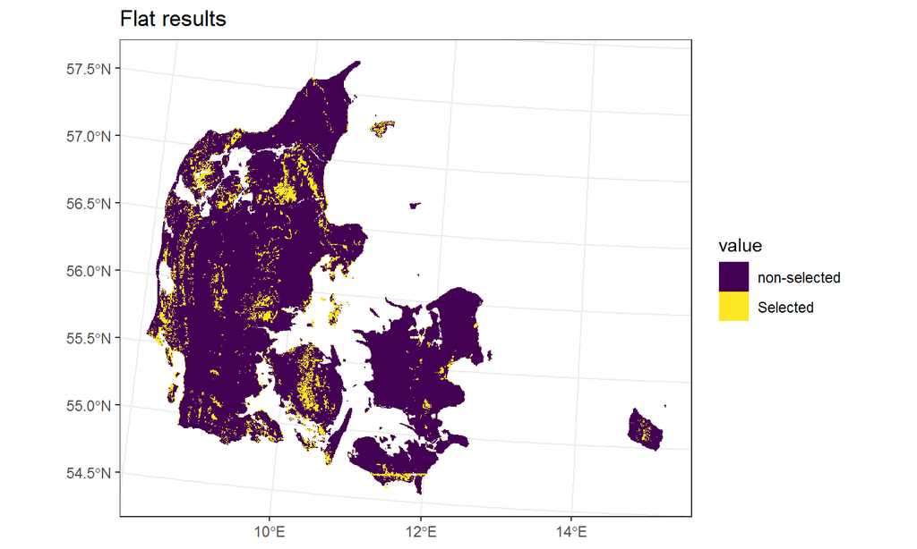

## Add Agriculture

- Add Agriculture as cost (min cost)

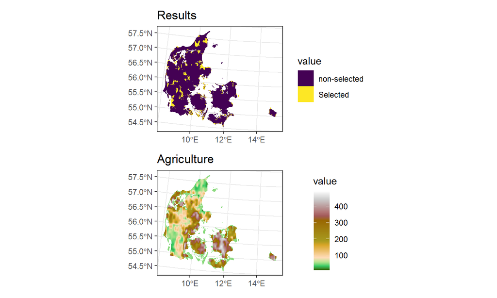

## Add agriculture (cont)

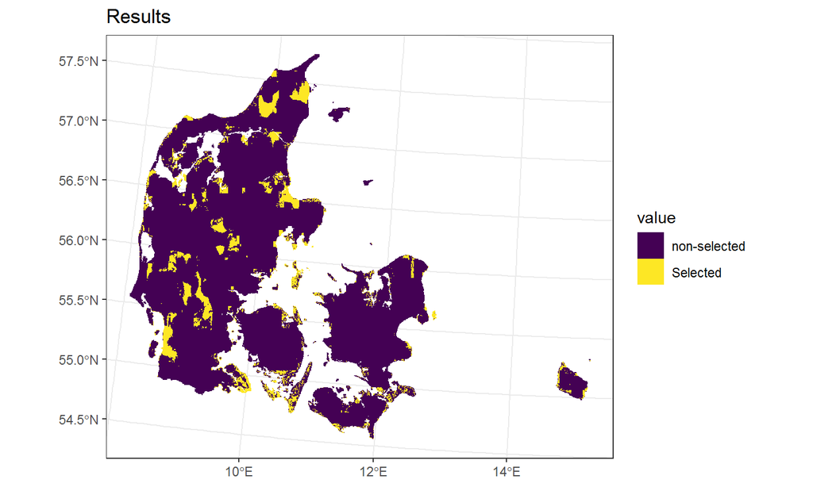

## We dont start from scratch

- Start with protected areas, eliminate cities (HFP)

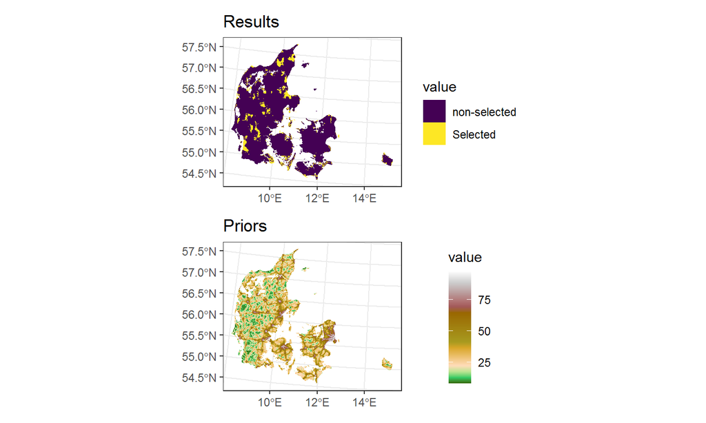

## We dont start from scratch (cont)

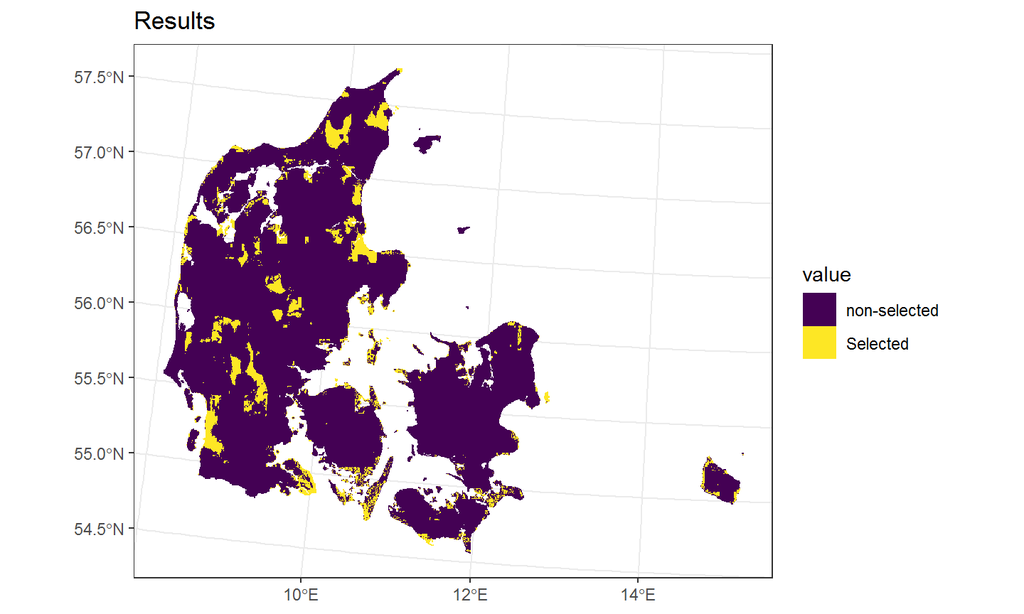

## Using weights and different budgets

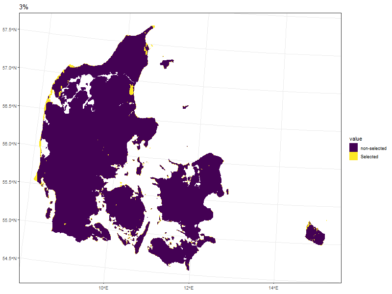

## closest to 10 and 30%

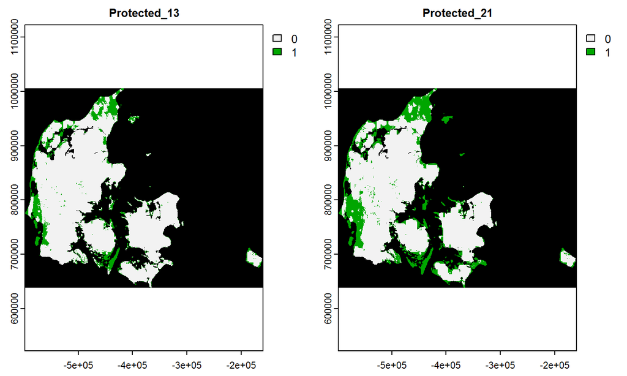